# Python

## Pandas Column Types

- Unlike `numpy`, `pandas` DataFrames can contain multiple types - each column has a type.
- Each column is a `Series` - a one dimensional structure with a single type
- We can index on columns `df['Price']` to access each Series
- Index on row names using the `.loc` property: `df.loc['1/2/09 13:08']`
- Index rows by integer index using `.iloc` property: `df.iloc[3]` or slides `df.iloc[1:10]`

| Operation | Syntax | Result |
| --- | --- | --- |
| Select column | `df[col]` | Series |
| Select row by label | `df.loc[label]` | Series |
| Select row by integer location | `df.iloc[loc]` | Series |
| Slice rows | `df[5:10]` | DataFrame |
| Select rows by boolean vector | `df[bool_vec]` | DataFrame |

```python
df['Price'][:3]
```

```
Transaction_date
1/02/2009 06:17    1200
1/02/2009 04:53    1200
1/02/2009 13:08    1200
Name: Price, dtype: object
```

```python
# get one row
df.loc['1/02/2009 13:08']
```

[output not shown]

```python
df.iloc[1:3]
```

| Transaction_date | Product | Price | Payment_Type | Name | City | State | Country | Account_Created | Last_Login | Latitude | Longitude |
| --- | --- | --- | --- | --- | --- | --- | --- | --- | --- | --- | --- |
| 1/02/2009 04:53 | Product1 | 1200 | Visa | Betina | Parkville | MO | United States | 1/02/2009 04:42 | 1/02/2009 07:49 | 39.19500 | -94.68194 |
| 1/02/2009 13:08 | Product1 | 1200 | Mastercard | Federica e Andrea | Astoria | OR | United States | 1/01/2009 16:21 | 1/03/2009 12:32 | 46.18806 | -123.83000 |

## Selecting Data

- Pandas supports a wide range of operations on DataFrames and Series to select data
- Can be similar in power to database operations
- Eg. select rows for one value of some column

```python
#df[df['Payment_Type'] == 'Visa'].iloc[:3]

df[df['Payment_Type'] == 'Visa'].iloc[:3]
```

| Transaction_date | Product | Price | Payment_Type | Name | City | State | Country | Account_Created | Last_Login | Latitude | Longitude |
| --- | --- | --- | --- | --- | --- | --- | --- | --- | --- | --- | --- |
| 1/02/2009 04:53 | Product1 | 1200 | Visa | Betina | Parkville | MO | United States | 1/02/2009 04:42 | 1/02/2009 07:49 | 39.195000 | -94.68194 |
| 1/03/2009 14:44 | Product1 | 1200 | Visa | Gouya | Echuca | Victoria | Australia | 9/25/05 21:13 | 1/03/2009 14:22 | -36.133333 | 144.75000 |
| 1/04/2009 12:56 | Product2 | 3600 | Visa | Gerd W | Cahaba Heights | AL | United States | 11/15/08 15:47 | 1/04/2009 12:45 | 33.520560 | -86.80250 |

## Plotting

- Pandas has some simple options for [plotting data](http://pandas.pydata.org/pandas-docs/stable/visualization.html)
- The `.plot()` method will generate a default line graph of numerical columns
- Other methods for scatter plots, bar charts etc.

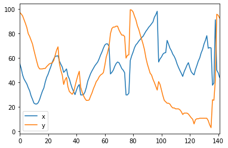

```python
%matplotlib inline
ds1 = pd.read_csv("files/ds1.csv")
ds1.plot()
```

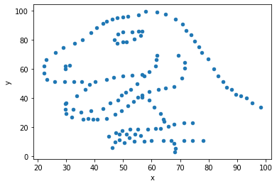

```python
ds1.plot.scatter(x="x", y="y")
```

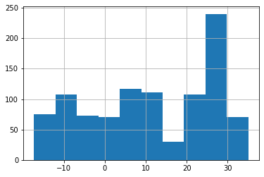

```python
%matplotlib inline

ts = pd.Series(np.random.randn(1000), index=pd.date_range('1/1/2000', periods=1000))
ts = ts.cumsum()
# plot, hist,
ts.hist()
```

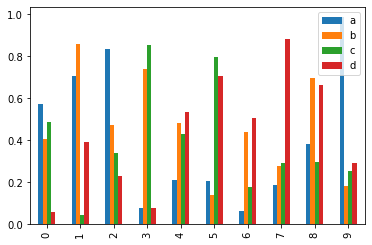

```python
df2 = pd.DataFrame(np.random.rand(10, 4), columns=['a', 'b', 'c', 'd'])
df2.plot.bar()
```